# Analysis for quantifying electricity supply security in South Korea

Kenneth Piech

10/4/2021

This is an R markdown document recording analysis for *Quantifying electricity supply security in South Korea: historical values and projections* by Kenneth Piech.

In section 1 we will load packages and data to prepare for analysis. In section 2 we format data and perform calculations to prepare for analysis. In section 3 we calculate and visualize values of ESMC, and we calculate and visualize values of ESPI in section 4. In section 5 we create a table documenting the results of our ESMC calculations for each fuel type, and in section 6 we produce a visualization of electricity generation by fuel type for South Korea.

# 1. Prepare for analysis

### 1.1 Load packages

```r
# install packages

# install.packages("dplyr")
# install.packages("here")
# install.packages("hrbrthemes")
# install.packages("janitor")
# install.packages("skimr")
# install.packages("tidyverse")
# install.packages("viridis")
# install.packages("webshot")

#load packages

library(dplyr)
```

```r
library(ggplot2)
library(gt)
library(hrbrthemes)
library(janitor)
library(readr)
library(tidyr)
library(tidyverse)
library(viridis)
library(webshot)
```

```r
#use Times New Roman font for visualizations

windowsFonts(A = windowsFont("Times New Roman"))

hrbrthemes::import_roboto_condensed()
```

```
## You will likely need to install these fonts on your system as well.
##
## You can find them in [C:/Users/piech/Documents/R/win-library/4.1/hrbrthemes/fonts/roboto-condensed]
```

```r
library(webshot)

webshot::install_phantomjs(force = TRUE)
```

```
## phantomjs has been installed to C:\Users\piech\AppData\Roaming\PhantomJS
```

### 1.2 Import data

All world bank and EIA data sets were cleaned and placed in standardized format for merging and calculations.

```r
political_stability <- read_csv("https://raw.githubusercontent.com/kp145322/electricity_supply_security/main/political_stability.csv")
  View(political_stability)

regulatory_quality <- read_csv("https://raw.githubusercontent.com/kp145322/electricity_supply_security/main/regulatory_quality.csv")
  View(regulatory_quality)

rule_of_law <- read_csv("https://raw.githubusercontent.com/kp145322/electricity_supply_security/main/rule_of_law.csv")
  View(rule_of_law)
```

```r
eia_country_oil_exports <- read_csv("https://raw.githubusercontent.com/kp145322/electricity_supply_security/main/eia_country_oil_exports.csv")
  View(eia_country_oil_exports)
```

# 2. Format data for analysis

```r
#Merge political stability, regulatory quality, and rule of law data frames and
#adjust to create a political risk composite value.

political_join <- full_join(
  political_stability,
  regulatory_quality,
  by = NULL,
  copy = FALSE,
  suffix = c(".x", ".y"),
  keep = FALSE,
  na_matches = c("na", "never")
)
political_join_2 <- full_join(
  political_join,
  rule_of_law,
  by = NULL,
  copy = FALSE,
  suffix = c(".x", ".y"),
  keep = FALSE,
  na_matches = c("na", "never")
)
political_composite <- political_join_2 %>%
  rowwise() %>%
    mutate(
      risk_composite = mean(c(political_stability, regulatory_quality,
      rule_of_law))
    )

#risk_composite is an average of the three governance indices.
```

```r
#We will use political_risk_multiplier to calculate ESMC and ESPI values in
#sections 3 and 4. political_risk_multiplier ranges from 1 to 3.
#HHI values typically range from 0 to 10,000, and our values for ESMC will range
#from 0 to 30,000 due to the political_risk_multiplier.

political_risk_multiplier <-  mutate(
  political_composite, risk_multiplier = (
  (5 - (risk_composite + 2.5))*
  (2/5) + 1
  )
)
```

```r
oil_risk <- inner_join(
  political_risk_multiplier,
  eia_country_oil_exports,
  by = NULL,
  copy = FALSE,
  suffix = c(".x", ".y"),
  keep = FALSE,
  na_matches = c("na", "never")
)
```

# 3. Calculate and visualize ESMC for coal, oil, and gas

### 3.1 Calculate ESMC_oil

```r
oil_risk_market_share_squared <- mutate(
  oil_risk, "market_share_squared" =
  (country_oil_exports_mb_per_day * 100 / global_oil_exports_mb_per_day)^2
)

oil_risk_RWMS <- mutate(
  oil_risk_market_share_squared, "RWMS" = market_share_squared * risk_multiplier
)

oil_risk_RWMS_no_na <- na.omit(oil_risk_RWMS)

global_oil_ESMC <- oil_risk_RWMS_no_na %>%
  group_by(year) %>%
  summarise(ESMC = sum(RWMS))
```

### 3.2 Calculate ESMC_coal

We use “thermal coal” export data as reported by the EIA, which correspondes to the anthracite, bituminous, and sub-bituminous coals used for electricity in South Korea.

```r
eia_country_coal_exports <- read_csv("https://raw.githubusercontent.com/kp145322/electricity_supply_security/main/eia_country_coal_exports.csv")
  View(eia_country_coal_exports)

coal_risk <- inner_join(
  political_risk_multiplier,
  eia_country_coal_exports,
  by = NULL,
  copy = FALSE,
  suffix = c(".x", ".y"),
  keep = FALSE,
  na_matches = c("na", "never")
)
coal_risk_market_share_squared <- mutate(
  coal_risk, "market_share_squared" = (
    (
      (as.numeric(country_thermal_coal_exports_per_year)) * 100 /
      (as.numeric(world_thermal_coal_exports_per_year)
       )
    )^2
  )
)

coal_risk_RWMS <- mutate(
  coal_risk_market_share_squared, "RWMS" = market_share_squared *
  risk_multiplier
)

coal_risk_RWMS_no_na <- na.omit(coal_risk_RWMS)

global_coal_ESMC <- coal_risk_RWMS_no_na %>%
  group_by(year) %>%
  summarise(ESMC = sum(RWMS))
```

### 3.3 Calculate ESMC_gas

```r
eia_country_gas_exports <- read_csv("https://raw.githubusercontent.com/kp145322/electricity_supply_security/main/eia_country_gas_exports.csv")
  View(eia_country_gas_exports)

gas_risk <- inner_join(
  political_risk_multiplier,
  eia_country_gas_exports,
  by = NULL,
  copy = FALSE,
  suffix = c(".x", ".y"),
  keep = FALSE,
  na_matches = c("na", "never")
)
gas_risk_market_share_squared <- mutate(
  gas_risk, "market_share_squared" = (
    ( (as.numeric(country_gas_exports)) * 100 / (as.numeric(world_gas_exports))
    )^2
  )
)
```

[output not shown]

[output cut: 78 more lines]

[output not shown]

```r
gas_risk_RWMS <- mutate(
  gas_risk_market_share_squared, "RWMS" = market_share_squared *
  risk_multiplier
)

gas_risk_RWMS_no_na <- na.omit(gas_risk_RWMS)

global_gas_ESMC <- gas_risk_RWMS_no_na %>%
  group_by(year) %>%
  summarise(ESMC = sum(RWMS))

global_gas_ESMC_1 <- rename(global_gas_ESMC, ESMC_gas = ESMC)

global_oil_ESMC_1 <- rename(global_oil_ESMC, ESMC_oil = ESMC)

global_gas_ESMC_2 <- full_join(
  global_gas_ESMC_1,
  global_oil_ESMC_1,
  by = NULL,
  copy = FALSE,
  suffix = c(".x", ".y"),
  keep = FALSE,
  na_matches = c("na", "never")
)
#import spot-market proportion GIIGNL data

gas_spot_market_proportions <- read_csv("https://raw.githubusercontent.com/kp145322/electricity_supply_security/main/gas_spot_market_proportions.csv")
  View(gas_spot_market_proportions)

global_gas_ESMC_3 <-
  full_join(
  global_gas_ESMC_2,
  gas_spot_market_proportions,
  by = NULL,
  copy = FALSE,
  suffix = c(".x", ".y"),
  keep = FALSE,
  na_matches = c("na", "never")
)
global_gas_ESMC_4 <- na.omit(global_gas_ESMC_3)

#create weighted value for ESMC considering proportion of global spot-market vs. oil-indexed sales

global_gas_ESMC_weighted <- mutate(
  global_gas_ESMC_4,
  "ESMC" = (as.numeric(ESMC_gas))*gas_spot_market_proportion +
  (as.numeric(ESMC_oil))*gas_oil_indexed_proportion
)
```

### 3.4 Create a comprehensive ESMC dataframe

```r
global_coal_ESMC_1 = rename(global_coal_ESMC, "ESMC_coal" = "ESMC")

#create global gas ESMC weighed value to join with ESMC_coal

global_gas_ESMC_weighted_1 <- global_gas_ESMC_weighted[c(1,6)]

global_gas_ESMC_weighted_2 <- rename(
  global_gas_ESMC_weighted_1, ESMC_gas = ESMC
)

# join ESMC gas and oil to prepare to join to ESMC coal

global_gas_ESMC_weighted_3 <- full_join(
  global_gas_ESMC_weighted_2,
  global_oil_ESMC_1,
  by = NULL,
  copy = FALSE,
  suffix = c(".x", ".y"),
  keep = FALSE,
  na_matches = c("na", "never")
)
#join all ESMC values to make a comprehensive dataframe

global_ESMC_comprehensive <- full_join(
  global_gas_ESMC_weighted_3, global_coal_ESMC_1
)
```

### 3.5 Add projections for 2022, 2030, and 2034 to historical dataframes

We will assume ESMC for coal, gas, and oil each remain at the average of their levels from 2014-2018 through 2022, 2030, and 2034.

```r
X2014_to_2018_avg_ESMC_coal <- read_csv("https://raw.githubusercontent.com/kp145322/electricity_supply_security/main/2014_to_2018_avg_ESMC_coal.csv")
X2014_to_2018_avg_ESMC_gas <- read_csv("https://raw.githubusercontent.com/kp145322/electricity_supply_security/main/2014_to_2018_avg_ESMC_gas.csv")
X2014_to_2018_avg_ESMC_oil <- read_csv("https://raw.githubusercontent.com/kp145322/electricity_supply_security/main/2014_to_2018_avg_ESMC_oil.csv")
```

```r
#merge projected data with historical data for ESMC

global_gas_ESMC_projected_0 <- full_join(
  global_gas_ESMC_weighted,
  X2014_to_2018_avg_ESMC_gas,
  by = NULL,
  copy = FALSE,
  suffix = c(".x", ".y"),
  keep = FALSE,
  na_matches = c("na", "never")
)
global_gas_ESMC_projected <- global_gas_ESMC_projected_0[c(1:23),c(1,6)]

global_oil_ESMC_projected <- full_join(
  global_oil_ESMC,
  X2014_to_2018_avg_ESMC_oil,
  by = NULL,
  copy = FALSE,
  suffix = c(".x", ".y"),
  keep = FALSE,
  na_matches = c("na", "never"))
global_coal_ESMC_projected <- full_join(
  global_coal_ESMC,
  X2014_to_2018_avg_ESMC_coal,
  by = NULL,
  copy = FALSE,
  suffix = c(".x", ".y"),
  keep = FALSE,
  na_matches = c("na", "never"))
#rename ESMC for more specific ESMC values and merge dataframes for oil, coal,
#and gas

global_coal_ESMC_projected_1 = rename(
  global_coal_ESMC_projected, "ESMC_coal" = "ESMC"
)

global_gas_ESMC_projected_1 = rename(
  global_gas_ESMC_projected, "ESMC_gas" = "ESMC"
)

global_oil_ESMC_projected_1 = rename(
  global_oil_ESMC_projected, "ESMC_oil" = "ESMC"
)

#merge the three dataframes to create one dataframe with all historical and
#projected ESMC values

global_ESMC_coal_and_gas_projected <- full_join(
  global_coal_ESMC_projected_1, global_gas_ESMC_projected_1
)
global_ESMC_comprehensive_projected <- full_join(
  global_ESMC_coal_and_gas_projected, global_oil_ESMC_projected_1
)
```

### 3.6 Plot historical ESMC values

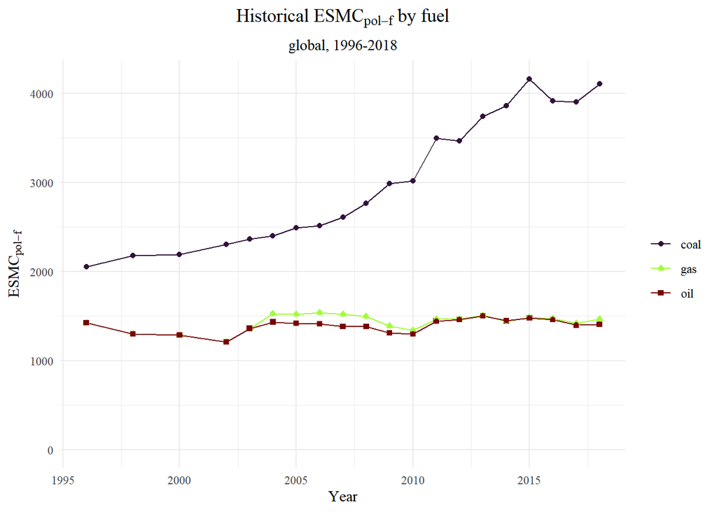

```r
global_coal_ESMC_long <- global_coal_ESMC %>%
  add_column(Fuel = "coal")

global_gas_ESMC_long <- global_gas_ESMC_weighted %>%
  add_column(Fuel = "gas")

#select only required variables to vertically merge gas data with coal and oil data

global_gas_ESMC_long_1 <- global_gas_ESMC_long[c(1,6:7)]

global_oil_ESMC_long <- global_oil_ESMC %>%
  add_column(Fuel = "oil")

#vertically merge coal, gas, and oil ESMC values to plot together

global_ESMC_comprehensive_long <- rbind(
  global_coal_ESMC_long, global_gas_ESMC_long_1, global_oil_ESMC_long
)

#plot all ESMC values together using comprehensive long data

global_ESMC_comprehensive_long %>%
  ggplot(mapping = aes(x=year, y=ESMC, color=Fuel)) +
  ylab(expression(paste("ESM",C[pol-f]))) +
  xlab(expression(paste("Year"))) +
  geom_line(method='lm', se=FALSE) +
  geom_point(aes(shape=Fuel)) +
  theme_minimal() +
  scale_colour_viridis(discrete = T, option = "H") +
  expand_limits(y=0) + geom_point() +
  labs(title=(expression(paste("Historical ESM", C[pol-f], " by fuel"))
              ), subtitle = "global, 1996-2018"
       ) +
  theme(plot.title = element_text(hjust = 0.5), plot.subtitle =
        element_text(hjust = 0.5)) +
  theme(legend.title = element_blank()) +
    theme(text = element_text(family = "A"))
```